# Прогнозирование оттока

1. Описание данных  
2. Исследование зависимостей и формулирование гипотез  
2.1. Анализ бинарных показателей  
2.2. Анализ непрерывных показателей  
2.3. Анализ корреляционной матрицы  
3. Построение моделей для прогнозирования оттока  
3.1. Открытая модель  
3.2. Закрытая модель  
3.3. Voting  
3.4. Stacking  
4. Сравнение качества моделей  
5. Пример использования модели для прогнозирования оттока  
5.1. Обучение  
5.2. Выбор порога принятия решения  
5.3. Демонстрация прогнозирования  
5.4. Предсказание с помощью модели стэкинга  
5.5. Возможные ошибки

Ссылка на исходный датасет (kaggle): [Telco Customer Churn](https://www.kaggle.com/datasets/blastchar/telco-customer-churn)

**Описание работы:**  
Любой бизнес хочет максимизировать количество клиентов. Для достижения этой цели важно не только пытаться привлечь новых, но и удерживать уже существующих. Удержать клиента обойдется компании дешевле, чем привлечь нового. Кроме того, новый клиент может оказаться слабо заинтересованным в услугах бизнеса и с ним будет сложно работать, тогда как о старых клиентах уже есть необходимые данные по взаимодействию с сервисом.

Соответственно, прогнозируя отток, мы можем вовремя среагировать и попытаться удержать клиента, который хочет уйти. Опираясь на данные об услугах, которыми пользуется клиент, мы можем сделать ему специальное предложение, пытаясь изменить его решение об уходе от оператора. Благодаря этому задача удержания будет легче в реализации, чем задача привлечения новых пользователей, о которых мы еще ничего не знаем.

Вам предоставлен набор данных от телекоммуникационной компании. В данных содержится информация о почти шести тысячах пользователей, их демографических характеристиках, услугах, которыми они пользуются, длительности пользования услугами оператора, методе оплаты, размере оплаты.

Cтоит задача проанализировать данные и спрогнозировать отток пользователей (выявить людей, которые продлят контракт и которые не продлят). Работа должна включать в себя следующие обязательные пункты:

1. Описание данных *(с расчетом базовых статистик)*,
2. Исследование зависимостей и формулирование гипотез,
3. Построение моделей для прогнозирования оттока *(с обоснованием выбора той или иной модели)* на основе проверенных гипотез и выявленных взаимосвязей,
4. Сравнение качества полученных моделей.

Во втором разделе обязательно должно присутствовать обоснование гипотез, подробное описание выявленных взаимосвязей, а также их визуализация.  
В четвертом дополнительно должны быть сформулированы общие выводы работы.

Codebook  
1. Описание данных  
2. Исследование зависимостей и формулирование гипотез  
3. Построение моделей для прогнозирования оттока  
4. Сравнение качества моделей

## Codebook

[Ссылка для скачивания данных](https://drive.google.com/open?id=1dPCG76ST6NohYKtVMGv6HpFL-jD5p1eJ)

`telecom_users.csv` содержит следующие значения:

`customerID` – id клиента  
`gender` – пол клиента (male/female)  
`SeniorCitizen` – яляется ли клиент пенсионером (1, 0)  
`Partner` – состоит ли клиент в браке (Yes, No)  
`Dependents` – есть ли у клиента иждивенцы (Yes, No)  
`tenure` – сколько месяцев человек являлся клиентом компании  
`PhoneService` – подключена ли услуга телефонной связи (Yes, No)  
`MultipleLines` – подключены ли несколько телефонных линий (Yes, No, No phone service)  
`InternetService` – интернет-провайдер клиента (DSL, Fiber optic, No)  
`OnlineSecurity` – подключена ли услуга онлайн-безопасности (Yes, No, No internet service)  
`OnlineBackup` – подключена ли услуга online backup (Yes, No, No internet service)  
`DeviceProtection` – есть ли у клиента страховка оборудования (Yes, No, No internet service)  
`TechSupport` – подключена ли услуга технической поддержки (Yes, No, No internet service)  
`StreamingTV` – подключена ли услуга стримингового телевидения (Yes, No, No internet service)  
`StreamingMovies` – подключена ли услуга стримингового кинотеатра (Yes, No, No internet service)  
`Contract` – тип контракта клиента (Month-to-month, One year, Two year)  
`PaperlessBilling` – пользуется ли клиент безбумажным биллингом (Yes, No)  
`PaymentMethod` – метод оплаты (Electronic check, Mailed check, Bank transfer (automatic), Credit card (automatic))  
`MonthlyCharges` – месячный размер оплаты на настоящий момент  
`TotalCharges` – общая сумма, которую клиент заплатил за услуги за все время  
`Churn` – произошел ли отток (Yes or No)

```python
# Configuration

# Cache directory used for sklearn's pipeline caching. Set to `None` to disable caching.
#   sklearn.pipeline.Pipeline(memory=CACHE_DIR)
CACHE_DIR = '_cache-ml-telecom-users'  # `None` to disable
REMOVE_CACHE = False                   # remove cache directory after completion
```

```python
# Utility functions

import re

def split_camel_case(cc_string):
    """
    >>> split_camel_case('HTTP2Service')
    ['HTTP2', 'Service']

    >>> split_camel_case('CellRangeA1Z99')
    ['Cell', 'Range', 'A1', 'Z99']

    >>> split_camel_case('customerID')
    ['customer', 'ID']
    """
    return re.split(r'(?<=\d)(?=\D)|(?<=[^A-Z\d])(?=[A-Z\d])|(?<!^)(?=[A-Z][a-z])', cc_string)

def camel_to_snake_case(cc_string):
    """ camel_to_snake_case('customerID') -> 'customer_id' """
    return '_'.join(split_camel_case(cc_string)).lower()
```

# 1. Описание данных

```python
import itertools
import shutil
import warnings

import numpy as np
import pandas as pd

import matplotlib as mpl
import matplotlib.pyplot as plt
import seaborn as sns
```

```python
df_raw = pd.read_csv('data/telecom_users.csv', index_col=0, na_values=[' '])
df_raw.dtypes.to_frame('Dtype').join(df_raw.head().T)

# Raw data imported:
```

|  | Dtype | 1869 | 4528 | 6344 | 6739 | 432 |
| --- | --- | --- | --- | --- | --- | --- |
| customerID | object | 7010-BRBUU | 9688-YGXVR | 9286-DOJGF | 6994-KERXL | 2181-UAESM |
| gender | object | Male | Female | Female | Male | Male |
| SeniorCitizen | int64 | 0 | 0 | 1 | 0 | 0 |
| Partner | object | Yes | No | Yes | No | No |
| Dependents | object | Yes | No | No | No | No |
| tenure | int64 | 72 | 44 | 38 | 4 | 2 |
| PhoneService | object | Yes | Yes | Yes | Yes | Yes |
| MultipleLines | object | Yes | No | Yes | No | No |
| InternetService | object | No | Fiber optic | Fiber optic | DSL | DSL |
| OnlineSecurity | object | No internet service | No | No | No | Yes |
| OnlineBackup | object | No internet service | Yes | No | No | No |
| DeviceProtection | object | No internet service | Yes | No | No | Yes |
| TechSupport | object | No internet service | No | No | No | No |
| StreamingTV | object | No internet service | Yes | No | No | No |
| StreamingMovies | object | No internet service | No | No | Yes | No |
| Contract | object | Two year | Month-to-month | Month-to-month | Month-to-month | Month-to-month |
| PaperlessBilling | object | No | Yes | Yes | Yes | No |
| PaymentMethod | object | Credit card (automatic) | Credit card (automatic) | Bank transfer (automatic) | Electronic check | Electronic check |
| MonthlyCharges | float64 | 24.1 | 88.15 | 74.95 | 55.9 | 53.45 |
| TotalCharges | float64 | 1734.65 | 3973.2 | 2869.85 | 238.5 | 119.5 |
| Churn | object | No | No | Yes | No | No |

```python
df_raw.info()
```

```
<class 'pandas.core.frame.DataFrame'>
Int64Index: 5986 entries, 1869 to 860
Data columns (total 21 columns):
 #   Column            Non-Null Count  Dtype
---  ------            --------------  -----
 0   customerID        5986 non-null   object
 1   gender            5986 non-null   object
 2   SeniorCitizen     5986 non-null   int64
 3   Partner           5986 non-null   object
 4   Dependents        5986 non-null   object
 5   tenure            5986 non-null   int64
 6   PhoneService      5986 non-null   object
 7   MultipleLines     5986 non-null   object
 8   InternetService   5986 non-null   object
 9   OnlineSecurity    5986 non-null   object
 10  OnlineBackup      5986 non-null   object
 11  DeviceProtection  5986 non-null   object
 12  TechSupport       5986 non-null   object
 13  StreamingTV       5986 non-null   object
 14  StreamingMovies   5986 non-null   object
 15  Contract          5986 non-null   object
 16  PaperlessBilling  5986 non-null   object
 17  PaymentMethod     5986 non-null   object
 18  MonthlyCharges    5986 non-null   float64
 19  TotalCharges      5976 non-null   float64
 20  Churn             5986 non-null   object
dtypes: float64(2), int64(2), object(17)
memory usage: 1.0+ MB
```

```python
# Пропущенные значения содержатся только в строках, где tenure = 0

df_raw[df_raw.tenure==0].TotalCharges.isna().sum()
```

```
10
```

Результаты первичного осмотра:

1. 5986 записей (соответствует описанию)
2. 21 колонка (включая целевую переменную *Churn*)
3. 10 пропущенных значений в колонке *TotalCharges* (новые абоненты со сроком менее 1 месяца)
4. Некоторые колонки требуют преобразования типов (object -> bool, int -> bool)

План подготовки данных:

1. Удалить столбец `customerID`.
2. Заполнить пропущенные значения в колонке *TotalCharges* нулями.
3. Отсортировать строки по индексу.
4. Преобразовать колонки со значениями Yes/No и 0/1 в тип boolean.
5. Преобразовать категориальные данные в boolean с помощью one-hot кодирования (`pd.get_dummies()`).
6. Привести имена колонок к единому формату для дальнейшей удобной работы с датасетом.

```python
# Подготовка данных

df = df_raw.copy()
df = df.drop(columns='customerID')  # (1)
df = df.fillna(0)                   # (2)
df = df.sort_index()                # (3)

yes_no_columns = [
    'Partner',
    'Dependents',
    'PhoneService',
    'MultipleLines',
    'OnlineSecurity',
    'OnlineBackup',
    'DeviceProtection',
    'TechSupport',
    'StreamingTV',
    'StreamingMovies',
    'PaperlessBilling',
    'Churn',
]

df[yes_no_columns] = df[yes_no_columns] == 'Yes'  # (4)
df.SeniorCitizen = df.SeniorCitizen == 1
df = pd.get_dummies(df, dtype=bool)               # (5)
df = df.drop(columns=['gender_Female'])
df['InternetService_No'] = ~df['InternetService_No']

column_names_mapping = {
    **dict(zip(df_raw.columns, df_raw.columns.map(camel_to_snake_case))),
    'gender_Male': 'is_male',
    'InternetService_DSL': 'internet_dsl',
    'InternetService_Fiber optic': 'internet_fiber',
    'InternetService_No': 'internet_service',
    'Contract_Month-to-month': 'contract_one_month',
    'Contract_One year': 'contract_one_year',
    'Contract_Two year': 'contract_two_year',
    'PaymentMethod_Bank transfer (automatic)': 'pay_auto_transfer',
    'PaymentMethod_Credit card (automatic)': 'pay_auto_credit',
    'PaymentMethod_Electronic check': 'pay_check_email',
    'PaymentMethod_Mailed check': 'pay_check_mail',
}

df = df.rename(columns=column_names_mapping)   # (6)
middle_columns = df.columns.drop(['churn', 'tenure', 'monthly_charges', 'total_charges'])
df = df[['churn', *middle_columns, 'tenure', 'monthly_charges', 'total_charges']]  # reorder columns
df.head(10).T
```

|  | 0 | 1 | 2 | 3 | 4 | 5 | 6 | 7 | 9 | 10 |
| --- | --- | --- | --- | --- | --- | --- | --- | --- | --- | --- |
| churn | False | False | True | False | True | True | False | False | False | False |
| senior_citizen | False | False | False | False | False | False | False | False | False | False |
| partner | True | False | False | False | False | False | False | False | False | True |
| dependents | False | False | False | False | False | False | True | False | True | True |
| phone_service | False | True | True | False | True | True | True | False | True | True |
| multiple_lines | False | False | False | False | False | True | True | False | False | False |
| online_security | False | True | True | True | False | False | False | True | True | True |
| online_backup | True | False | True | False | False | False | True | False | True | False |
| device_protection | False | True | False | True | False | True | False | False | False | False |
| tech_support | False | False | False | True | False | False | False | False | False | False |
| streaming_tv | False | False | False | False | False | True | True | False | False | False |
| streaming_movies | False | False | False | False | False | True | False | False | False | False |
| paperless_billing | True | False | True | False | True | True | True | False | False | True |
| is_male | False | True | True | True | False | False | True | False | True | True |
| internet_dsl | True | True | True | True | False | False | False | True | True | True |
| internet_fiber | False | False | False | False | True | True | True | False | False | False |
| internet_service | True | True | True | True | True | True | True | True | True | True |
| contract_one_month | True | False | True | False | True | True | True | True | False | True |
| contract_one_year | False | True | False | True | False | False | False | False | True | False |
| contract_two_year | False | False | False | False | False | False | False | False | False | False |
| pay_auto_transfer | False | False | False | True | False | False | False | False | True | False |
| pay_auto_credit | False | False | False | False | False | False | True | False | False | False |
| pay_check_email | True | False | False | False | True | True | False | False | False | False |
| pay_check_mail | False | True | True | False | False | False | False | True | False | True |
| tenure | 1 | 34 | 2 | 45 | 2 | 8 | 22 | 10 | 62 | 13 |
| monthly_charges | 29.85 | 56.95 | 53.85 | 42.3 | 70.7 | 99.65 | 89.1 | 29.75 | 56.15 | 49.95 |
| total_charges | 29.85 | 1889.5 | 108.15 | 1840.75 | 151.65 | 820.5 | 1949.4 | 301.9 | 3487.95 | 587.45 |

```python
# Статистика по бинарным показателям (type=bool)

df_bool = df.loc[:, df.dtypes=='bool']
df_bool_true_rate = df_bool.sum() / df_bool.count()
df_bool_stats = pd.DataFrame({
    'true_rate': df_bool_true_rate,
    'false_rate': 1 - df_bool_true_rate})
```

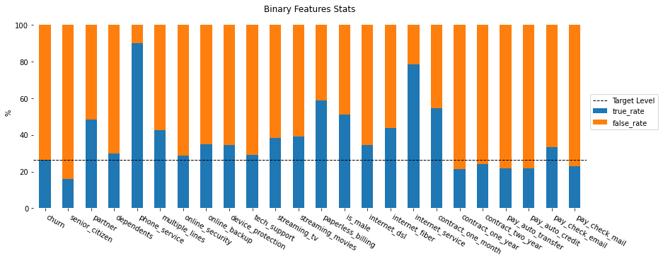

```python
(df_bool_stats * 100).plot.bar(figsize=(14, 5), rot=-30, stacked=True)
plt.axhline(df_bool_true_rate.churn * 100, c='k', lw='1', ls='--', label='Target Level')
plt.xticks(ha='left')
plt.legend(loc='center left', bbox_to_anchor=(1, 0.5))
plt.box()
plt.ylabel('%')
plt.title('Binary Features Stats')
pass
```

```python
# Статистика по числовым (continuous) показателям

df.describe(exclude=bool).T
```

|  | count | mean | std | min | 25% | 50% | 75% | max |
| --- | --- | --- | --- | --- | --- | --- | --- | --- |
| tenure | 5986.0 | 32.468760 | 24.516391 | 0.00 | 9.0000 | 29.000 | 56.0 | 72.00 |
| monthly_charges | 5986.0 | 64.802213 | 30.114702 | 18.25 | 35.6500 | 70.400 | 89.9 | 118.75 |
| total_charges | 5986.0 | 2294.221559 | 2274.164124 | 0.00 | 401.5875 | 1408.575 | 3841.5 | 8684.80 |

# 2. Исследование зависимостей и формулирование гипотез

## 2.1. Анализ бинарных показателей

```python
# Каждый бинарный показатель образует две группы: позитивную (=True) и негативную (=False).
# Например: contract_two_year и non_contract_two_year, is_male и non_is_male.
subdf_pos = df_bool.drop(columns='churn')
subdf_neg = ~subdf_pos.add_prefix('non_')

# Процент оттока (churn rate) считается по каждой группе, как позитивной так и негативной.
churn_pos = subdf_pos[df.churn].sum() / subdf_pos.sum()
churn_neg = subdf_neg[df.churn].sum() / subdf_neg.sum()

# Добавляем показатель общего оттока, в качестве "отправной точки" для оценки остальных уровней.
churn_rate_total = (df.sum() / df.count())['churn':'churn'].rename({'churn': 'churn_overall'})
churn_rates = pd.concat([churn_rate_total.rename(''), churn_pos, churn_neg])

churn_rates = churn_rates.sort_values()
```

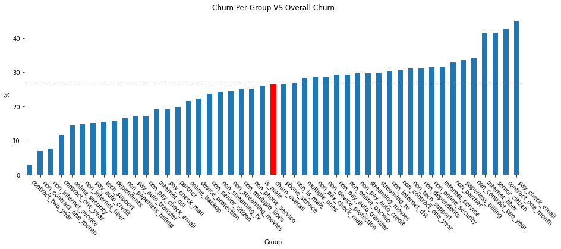

```python
overall_churn_index = churn_rates.index.tolist().index('churn_overall')
ax = (churn_rates * 100).to_frame().plot.bar(figsize=(15, 5), rot=-45, legend=None)
ax.axhline(churn_rates[overall_churn_index] * 100, c='k', lw=1, ls='--')
ax.patches[overall_churn_index].set_color('r')
plt.xticks(ha='left')
plt.title('Churn Per Group VS Overall Churn')
plt.xlabel('Group')
plt.ylabel('%')
plt.box()
pass
```

1. Отток значительно ниже среднего в группах абонентов:
   1. С долгосрочными контрактами (`contract_two_year`, `non_contract_one_month`, `contract_one_year`)
   2. Абонентов без услуги подключения к Интернету (`non_internet_service`)
2. Средний отток среди абонентов:
   1. Мужского и женского пола (`is_male`, `non_is_male`)
   2. С подключенной услугой сотовой связи и без неё (`phone_service`, `non_phone_service`)
3. Отток значительно выше среднего в группах абонентов:
   1. Получающих счет об оплате по email (`pay_check_email`)
   2. С краткосрочными контрактами (`contract_one_month`)
   3. Пенсионного возраста (`senior_citizen`)
   4. Пользователей услуги Интернет через оптоволоконную линию (`internet_fiber`)

Признаки первой и третьей группы являются хорошими индикаторами оттока, а признаки второй группы наоборот – наименее показательны.

## 2.2. Анализ непрерывных показателей

### 2.2.1. Показатель `total_charges`

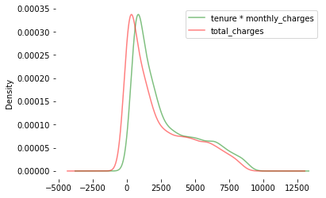

```python
# KDE plots

(df.tenure * df.monthly_charges + 500).plot.kde(color='green', alpha=.5, label=r'tenure * monthly_charges')
df.total_charges.plot.kde(color='red', alpha=.5, label='total_charges')
plt.box()
plt.legend();
```

```python
# Correlation matrix

np.corrcoef(df.total_charges, df.tenure * df.monthly_charges)
```

```
array([[1.        , 0.99956435],
       [0.99956435, 1.        ]])
```

Показатель `total_charges` близок к линейной комбинации двух показателей: `tenure * monthly_charges` (корреляция $\approx 1$), однако как показывает практика, удаление этого показателя ухудшает качество прогнозирования.

### 2.2.2. Анализ распределения числовых показателей

```python
# Коэффициенты асимметрии и эксцесса для числовых показателей

df_cont = df[['tenure', 'monthly_charges', 'total_charges']]
df_cont.agg(['skew', 'kurt'])
```

|  | tenure | monthly_charges | total_charges |
| --- | --- | --- | --- |
| skew | 0.233822 | -0.218678 | 0.951272 |
| kurt | -1.386832 | -1.259671 | -0.260961 |

Распределение переменных не соответствует нормальному, о чем свидетельствуют коэффициенты асимметрии (skew) и избыточного эксцесса (`kurt - 3`) отличные от нуля, а также форма гистограмм на следующем изображении.

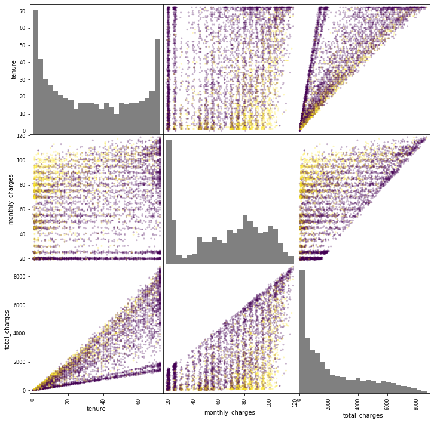

```python
# Scatter matrix

pd.plotting.scatter_matrix(df_cont, c=df.churn, figsize=(12, 12),
                           hist_kwds={'color': 'gray', 'bins': 25}, diagonal='hist', alpha=.3)
pass
# purple: churn=0, yellow: churn=1
```

1. Риск оттока *увеличивается* с ростом размера абонентской платы.
2. Риск оттока *уменьшается* с ростом лояльности клиента (показатель *tenure*).
3. Второй график, верхняя строка: видны вертикальные группы точек (решетка с шагом 5), которые могут представлять различные тарифные планы (20, 25, 30, ... USD/month).
4. Ярче всего выражены две первые группы – два популярных, недорогих тарифных плана.
5. Ни на одном из графиков нет четкого разделения между классами (churn=False и churn=True).

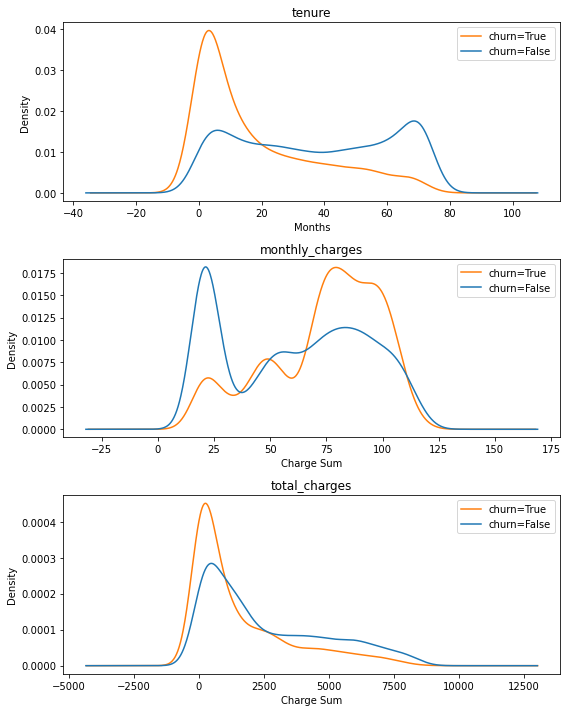

```python
# KDE plot

cmap = plt.rcParams['axes.prop_cycle'].by_key()['color']

axes = df_cont[df.churn].plot.kde(subplots=True, sharex=False, figsize=(8, 10), color=cmap[1])
df_cont[~df.churn].plot.kde(subplots=True, sharex=False, figsize=(8, 10), color=cmap[0], ax=axes)

for ax, title in zip(axes, df_cont.columns):
    ax.legend(['churn=True', 'churn=False'])
    ax.set_title(title)

axes[0].set_xlabel('Months')
axes[1].set_xlabel('Charge Sum')
axes[2].set_xlabel('Charge Sum')
plt.tight_layout()
```

1. Индикаторы высокого риска оттока:
   1. `tenure < 20`: показатель *лояльности* менее 20 месяцев.
   2. `70 < monthly_charges < 110`: размер ежемесячной абонентской платы в диапазоне 70-110.
2. На графике показателя *monthly_charges (churn=True)* можно выделить четыре пика (мультимодальное распределение):
   1. `25`: недорогие тарифные планы
   2. `50`: тарифные планы среднего ценового диапазона
   3. `75, 100`: тарифные планы высокого ценового диапазона

```python
# Tenure index frequency

(df.tenure.value_counts().head().rename_axis('tenure').to_frame('freq') / df.index.size).style.format('{:.0%}')
```

| tenure | freq |
| --- | --- |
| 1 | 9% |
| 72 | 5% |
| 2 | 3% |
| 3 | 3% |
| 4 | 3% |

1. Большинство клиентов (9%) пользуются услугами менее 1 месяца.
2. На втором месте (5%) группа постоянных клиентов (с максимальным сроком – 6 лет).

## 2.3. Анализ корреляционной матрицы

```python
# Correlation matrix

df_corr = df.corr(method='spearman')
```

Коэффициент корреляции Пирсона (Pearson) $r$, используемый по-умолчанию, подразумевает (assumptions):

1. Непрерывность данных (continuos).
2. Нормальное распределение.
3. Гомоскедастичность (англ. homoscedasticity), т.е на диаграмме рассеяния точки образуют "коридор" постоянной ширины.

Поскольку для исследуемых данных эти условия не выполняются, используется коэффициент корреляции Спирмена (Spearman) $\rho$ ("ro"), т.к. он не подразумевает конкретного распределения (distribution-free).

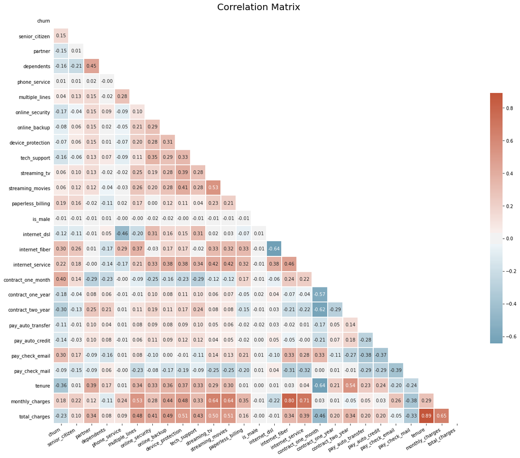

```python
# Plot correlation matrix as a heatmap

fig, ax = plt.subplots(figsize=(20, 20))
mask = np.triu(np.ones_like(df_corr, dtype=bool))
cmap = sns.diverging_palette(230, 20, as_cmap=True)

sns.heatmap(df_corr, cmap=cmap, mask=mask, square=True, cbar_kws={"shrink": .5}, annot=True, fmt='.2f',
            center=0, lw=1)
plt.xticks(rotation=30, ha='right')
plt.yticks()
plt.tick_params(left=False)
plt.title('Correlation Matrix', size=20)
pass
```

Примечательные корреляции:

**Гипотеза 1**. К оттоку склонны новые клиенты.

**Гипотеза 2**. К оттоку склонны клиенты, с краткосрочным контрактом (1 месяц).

**Гипотеза 3**. К оттоку склонны пользователи дорогих тарифных планов (высокая абонентская плата).

**Гипотеза 4**. К оттоку склонны пользователи услуги Интернет через оптоволокно.

# 3. Построение моделей для прогнозирования оттока

```python
import time

import sklearn
import sklearn.neural_network
import sklearn.discriminant_analysis
import sklearn.ensemble
import sklearn.gaussian_process
import sklearn.linear_model
import sklearn.naive_bayes
import sklearn.neural_network
import sklearn.neighbors
import sklearn.svm
import sklearn.tree

import xgboost

from sklearn.preprocessing import RobustScaler
from sklearn.compose import ColumnTransformer, make_column_selector
from sklearn.pipeline import Pipeline

from sklearn.model_selection import cross_val_score

from sklearn.ensemble import StackingClassifier, VotingClassifier
from sklearn.tree import DecisionTreeClassifier, plot_tree

# Prevent matplotlib annotation overlapping using force-based text position auto-ajustment
from adjustText import adjust_text
```

## 3.1. Открытая модель

*White box* – открытая модель с прозрачной логикой прогнозирования.

```python
SEED = 42
```

```python
# Подготавливаем матрицу объектов-признаков (X) и целевую переменную (y) для обучения моделей

df_shaffled = df.sample(frac=1, random_state=SEED)
X = df_shaffled.drop(columns='churn')
y = df_shaffled.churn
```

```python
dtc = DecisionTreeClassifier(max_depth=4, class_weight='balanced', min_samples_leaf=0.01, random_state=SEED)
dtc.fit(X, y)
```

```
DecisionTreeClassifier(class_weight='balanced', max_depth=4,
                       min_samples_leaf=0.01, random_state=42)
```

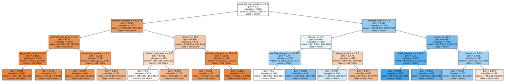

```python
# Decision tree diagram

plt.figure(figsize=(60, 10))
plot_tree(dtc, filled=True, fontsize=14, feature_names=X.columns, class_names=['not churn', 'churn']);
```

*(Jupyter Notebook: double click to zoom)*

На диаграмме: левая ветвь ← True, правая ветвь → False.

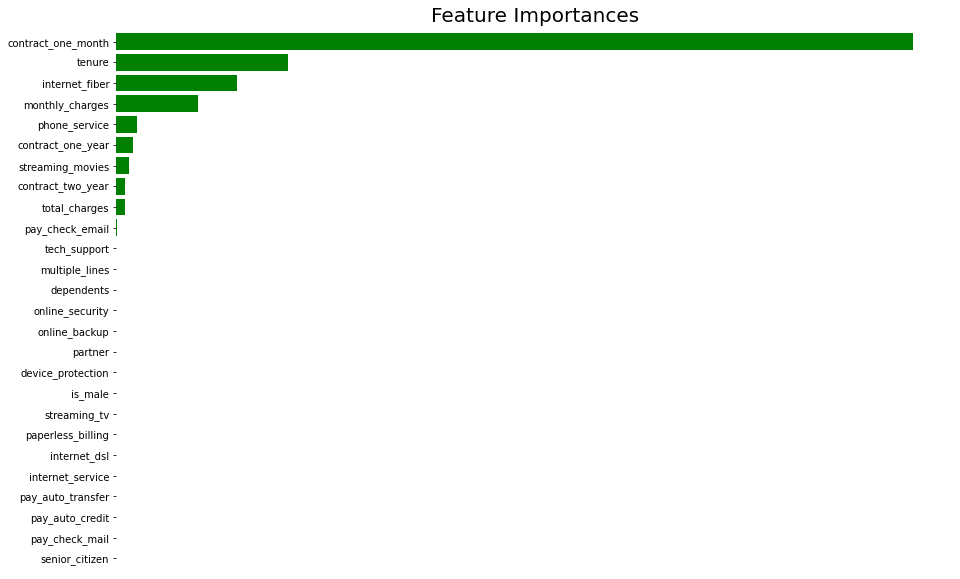

```python
# Feature importances

pd.Series(dtc.feature_importances_, index=X.columns).sort_values().plot.barh(figsize=(15, 10), width=.8, color='g')
plt.title('Feature Importances', size=20)
plt.box()
plt.xticks([])
pass
```

Простая модель дерева решений наглядно показывает наиболее значимые для прогнозирования оттока признаки:

```python
cross_val_score(dtc, X, y, n_jobs=-1, cv=4, scoring='roc_auc').mean()

# ROC AUC Score:
```

```
0.8282613761909807
```

Модель на базе дерева решений имеет наглядную интерпретацию, но для достижения максимальной точности необходимо использовать более сложные закрытые модели и их комбинации (ансамбли).

## 3.2. Закрытая модель

*Black box* – закрытая модель, нацеленная на прогнозирование с максимальной точностью.

Оптимизация гиперпараметров выполнена с помощью [визуального поиска по сетке](https://d-01.github.io/static/jupyter-export/sf-grid-hpo.html).

```python
classifiers = {
    "QDA"                : sklearn.discriminant_analysis.QuadraticDiscriminantAnalysis(
        reg_param=.0001
    ),
    "AdaBoost"           : sklearn.ensemble.AdaBoostClassifier(
        learning_rate=.5,
    ),
    "ExtraTrees"         : sklearn.ensemble.ExtraTreesClassifier(
        min_samples_split=.01,
        max_features=10,
        bootstrap=True,
        class_weight='balanced_subsample',
        max_samples=.5,
    ),
    "GradientBoosting"   : sklearn.ensemble.GradientBoostingClassifier(
        min_samples_leaf=.1,
    ),
    "RandomForest"       : sklearn.ensemble.RandomForestClassifier(
        max_depth=6,
        n_estimators=5000,
        max_samples=.1,
        min_samples_leaf=2,
        min_samples_split=.0001,
    ),
    "LogisticRegression" : sklearn.linear_model.LogisticRegression(
        n_jobs=-1,
        class_weight='balanced',
    ),
    "SGD"                : sklearn.linear_model.SGDClassifier(
        loss='log',
        penalty='elasticnet',
        learning_rate='adaptive',
        class_weight='balanced',
        l1_ratio=1.0,
        alpha=.001,
        eta0=0.1,
        max_iter=1000,
    ),
    "GaussianNB"         : sklearn.naive_bayes.GaussianNB(),
    "MLP"                : sklearn.neural_network.MLPClassifier(
        early_stopping=True,
        batch_size=100,
        activation='tanh',
        learning_rate_init=.01,
    ),
    "KNeighbors"         : sklearn.neighbors.KNeighborsClassifier(
        n_jobs=-1,
        n_neighbors=100,
    ),
    "SVC"                : sklearn.svm.SVC(
        probability=True,

        kernel='linear',
        gamma='auto',
        class_weight='balanced',
    ),
    "NuSVC"              : sklearn.svm.NuSVC(
        probability=True,

        kernel='linear',
        gamma='auto',
        class_weight='balanced',
    ),
    "DecisionTree"       : sklearn.tree.DecisionTreeClassifier(
        min_samples_split=.1,
        class_weight='balanced',
        ccp_alpha=.0001,
    ),
    "XGB"                : xgboost.XGBClassifier(
        use_label_encoder=False,
        eval_metric='logloss',
        n_jobs=-1,
        verbosity=0,

        max_depth=2,
        reg_alpha=2,
        learning_rate=0.1,
    ),
}
```

*Утечка информации (data leakage)* из тренировочных в тестовые данные происходит в результате предварительной трансформации всего датасета (например нормализация, до CV/Train/Test split), что приводит к завышенной оценке производительности модели. Чтобы избежать этого необходимо обрабатывать тренировочные и тестовые данные раздельно.

Наладить предобработку входных данных можно с помощью объекта `Pipeline`.

```python
# Для каждого классификатора создается конвейер, нормализующий числовые колонки во входных данных.

numeric_columns_selector = make_column_selector(dtype_include=np.number)  # boolean dtype is not included
numeric_columns = numeric_columns_selector(X)
numeric_columns_idx = np.flatnonzero(X.columns.isin(numeric_columns))

preprocessor = ColumnTransformer(
    remainder='passthrough',
    transformers=[('scaler', RobustScaler(), numeric_columns_idx)]
)

# Classifier -> Pipeline
for k, clf in classifiers.items():
    if 'random_state' in clf.get_params():
        clf.set_params(random_state=SEED)
    classifiers[k] = Pipeline([('pre', preprocessor), ('clf', clf)], memory=CACHE_DIR)
```

```python
def _time_score_table_cv(estimators):
    """ Train and evaluate each model. Return results as dataframe.
    """
    columns = 'fit_time_ms', 'auc_score', 'clf_name'
    table = []

    # Warm up cache for fair results
    if CACHE_DIR is not None:
        list(estimators.values())[0].fit(X, y)

    for i, [clf_name, clf] in enumerate(estimators.items()):
        print('%d.' % i, clf_name, end=' ')
        t1 = time.time_ns()
        auc_score = cross_val_score(clf, X, y, n_jobs=-1, cv=4, scoring='roc_auc').mean()

        t2 = time.time_ns()
        fit_time_ms = (t2 - t1) / 1e6
        print('(%.3f s)' % (fit_time_ms/1000))
        table.append([fit_time_ms, auc_score, clf_name])

    return pd.DataFrame(table, columns=columns)
```

```python
def _plot_tpt(time_score_table, figsize=(12, 6)):
    """ Create plot from dataframe with time-score data.
    """
    display(time_score_table.nlargest(1, 'auc_score').rename_axis(columns='BEST').iloc[:, -2:])

    fig, ax = plt.subplots(figsize=figsize)

    color_cycle = itertools.cycle(mpl.cm.tab20.colors)
    for row in time_score_table.itertuples():
        ax.scatter(row.fit_time_ms, row.auc_score, 80, label=row.clf_name, color=next(color_cycle), zorder=10)

    texts = time_score_table.apply(lambda row: ax.text(*row, zorder=11), axis=1)

    plt.xscale('log')
    plt.legend(loc='upper left', bbox_to_anchor=(1, 1))
    plt.xlabel('Fit Time, ms')
    plt.ylabel('ROC AUC Score')
    plt.title('Time-Performance Trade-Off', size=20)
    plt.grid(zorder=1)
    plt.box()

    plt.plot([0, 1], [.4, .7], transform=ax.transAxes, c='k', lw=1, ls='--', zorder=2)

    adjust_text(texts, time_score_table.fit_time_ms.values, time_score_table.auc_score.values,
                expand_points=(1.05, 1.5), expand_align=(1.05, 1.5))

    bbox_props = dict(boxstyle="larrow", facecolor='white', lw=2)
    ax.text(.2, .3, "          Better         ", ha="center", va="center", rotation=-80, size=15,
            bbox=bbox_props, transform=ax.transAxes, zorder=3)
```

```python
# Каждая модель обучается и оценивается на одном и том же наборе данных. Для оценки используется кросс-валидация
#   с 4-мя сбалансированными (stratified) фолдами. Время обучения и усредненная оценка записывается
#   в таблицу (pandas.DataFrame).

df_ts = _time_score_table_cv(classifiers)
```

```
0. QDA (0.170 s)
1. AdaBoost (1.348 s)
2. ExtraTrees (1.406 s)
3. GradientBoosting (1.768 s)
4. RandomForest (34.969 s)
5. LogisticRegression (0.360 s)
6. SGD (0.314 s)
7. GaussianNB (0.104 s)
8. MLP (3.550 s)
9. KNeighbors (1.783 s)
10. SVC (15.678 s)
11. NuSVC (11.460 s)
12. DecisionTree (0.085 s)
13. XGB (2.323 s)
```

| BEST | auc_score | clf_name |
| --- | --- | --- |
| 13 | 0.847193 | XGB |

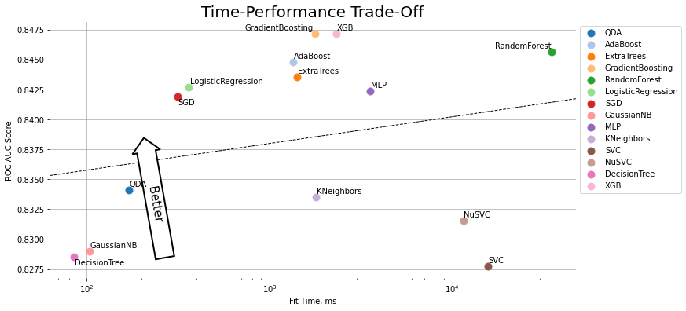

```python
_plot_tpt(df_ts)
```

1. Дерево решений (*DecisionTree*) уступает большинству алгоритмов в точности прогнозирования.
2. Относительно простая модель логистической регрессии показывает неплохую точность при сравнительно быстром обучении.
3. Наибольшую точность показывают модели на основе ансамблей решающих деревьев: *Gradient Boosting* и *eXtreme Gradient Boosting (XGB)*.
4. Алгоритмы использующие метод опорных векторов (*SVC*) и метод ближайших соседей (*KNeighbors*) имеют низкую производительность в условиях текущей задачи.

```python
# Общий зачет классификаторов

scores = df_ts.set_index('clf_name')['auc_score']
```

## 3.3. Voting

```python
# Для голосования и стэкинга отбираем все классификаторы кроме SVC и NuSVC
#   т.к. они долго обучаются и имеют низкую точность.

classifiers_selected = classifiers.copy()
del classifiers_selected['SVC']
del classifiers_selected['NuSVC']
```

```python
clf_vote = VotingClassifier(list(classifiers_selected.items()), voting='soft', n_jobs=-1)
(clf_vote_scores := cross_val_score(clf_vote, X, y, n_jobs=-1, cv=4, scoring='roc_auc'))
```

```
array([0.83778338, 0.82786467, 0.87135202, 0.84641185])
```

```python
# Добавить среднюю оценку голосования в общий зачет

scores['Voting'] = clf_vote_scores.mean()
```

## 3.4. Stacking

```python
meta_alg = sklearn.ensemble.RandomForestClassifier(max_depth=6, max_samples=0.1, min_samples_leaf=2,
                       min_samples_split=0.0001, n_estimators=5000, random_state=SEED)
stack = StackingClassifier(list(classifiers_selected.items()), meta_alg, cv=3, n_jobs=-1)
(stacking_score := cross_val_score(stack, X, y, n_jobs=-1, cv=4, scoring='roc_auc'))
```

```
array([0.83752233, 0.83027135, 0.87074464, 0.85008494])
```

```python
# Добавить среднюю оценку стэкинга в общий зачет

scores['Stacking'] = stacking_score.mean()
```

# 4. Сравнение качества моделей

```python
# Отсортировать и вывести таблицу с оценками

scores = scores.sort_values()
scores[::-1].to_frame()
```

| clf_name | auc_score |
| --- | --- |
| XGB | 0.847193 |
| Stacking | 0.847156 |
| GradientBoosting | 0.847148 |
| Voting | 0.845853 |
| RandomForest | 0.845676 |
| AdaBoost | 0.844780 |
| ExtraTrees | 0.843539 |
| LogisticRegression | 0.842712 |
| MLP | 0.842373 |
| SGD | 0.841930 |
| QDA | 0.834124 |
| KNeighbors | 0.833526 |
| NuSVC | 0.831547 |
| GaussianNB | 0.828962 |
| DecisionTree | 0.828499 |
| SVC | 0.827724 |

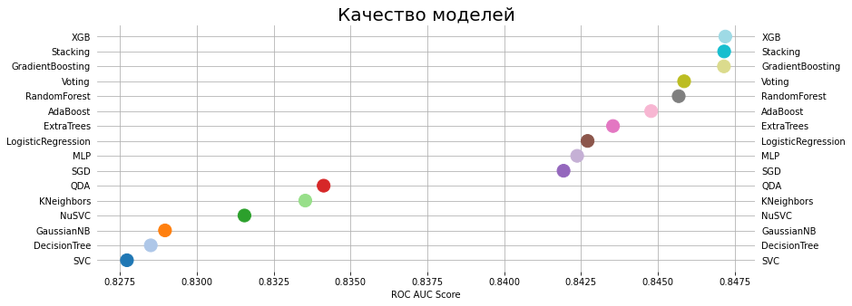

```python
# Вывести оценки в виде точечной диаграммы

plt.figure(figsize=(13, 5))
plt.scatter(scores, scores.index, s=200, c=mpl.cm.get_cmap('tab20', len(scores)).colors, zorder=2)
plt.box()
plt.grid(zorder=1)
plt.xlabel('ROC AUC Score')
plt.title('Качество моделей', size=20)
plt.tick_params(axis='y', which='both', left=False, right=False, labelright=True)
pass
```

**Результаты:**

1. Максимального качества классификации удалось добиться с помощью `XGBoost` классификатора.
2. Не удалось улучшить точность базовых классификаторов с помощью стэкинга.
3. Качество классификации по метрике ROC AUC составило: `0.847193`.

# 5. Пример использования модели для прогнозирования оттока

## 5.1. Обучение

```python
from sklearn.metrics import confusion_matrix, ConfusionMatrixDisplay
```

```python
# Первые 100 сэмплов датасета для демонстрации прогнозирования

X_train, X_test, y_train, y_test = X[100:], X[:100], y[100:], y[:100]
```

```python
%%time

classifiers_fitted = classifiers.copy()
for clf_name, clf in classifiers_fitted.items():
    print('Fitting: %s' % clf_name)
    clf.fit(X_train, y_train)

print('Fitting: Voting')
classifiers_fitted['Voting'] = clf_vote.fit(X_train, y_train)
print('Fitting: Stacking')
classifiers_fitted['Stacking'] = stack.fit(X_train, y_train)
```

```
Fitting: QDA
Fitting: AdaBoost
```

```
Fitting: ExtraTrees
Fitting: GradientBoosting
Fitting: RandomForest
Fitting: LogisticRegression
Fitting: SGD
Fitting: GaussianNB
Fitting: MLP
Fitting: KNeighbors
Fitting: SVC
Fitting: NuSVC
Fitting: DecisionTree
Fitting: XGB
Fitting: Voting
Fitting: Stacking
Wall time: 2min 18s
```

## 5.2. Выбор порога принятия решения

Для оценки производительности моделей была использована метрика ROC AUC, не зависящая от выбора порога принятия решения (threshold), далее "порог".

```python
threshold_default = 0.5
stack_y_pred = classifiers_fitted['Stacking'].predict(X_test)
stack_y_prob = classifiers_fitted['Stacking'].predict_proba(X_test)[:, 1]
stack_y_prob_thresholded = stack_y_prob > threshold_default
sum(stack_y_pred == stack_y_prob_thresholded)
```

```
100
```

Метод `predict()` всегда использует пороговое значение `0.5`, что может быть не лучшим выбором в условиях данной задачи.

```python
target = y_test.to_frame()
target['stack_prob']=classifiers_fitted['Stacking'].predict_proba(X_test)[:, 1]
target = target.sort_values('stack_prob')
target['churn_missed'] = target.churn.cumsum()

df_prob = target.join(X_test)
df_prob.style.format('{:.2%}', subset=['stack_prob'])
```

|  | churn | stack_prob | churn_missed | senior_citizen | partner | dependents | phone_service | multiple_lines | online_security | online_backup | device_protection | tech_support | streaming_tv | streaming_movies | paperless_billing | is_male | internet_dsl | internet_fiber | internet_service | contract_one_month | contract_one_year | contract_two_year | pay_auto_transfer | pay_auto_credit | pay_check_email | pay_check_mail | tenure | monthly_charges | total_charges |
| --- | --- | --- | --- | --- | --- | --- | --- | --- | --- | --- | --- | --- | --- | --- | --- | --- | --- | --- | --- | --- | --- | --- | --- | --- | --- | --- | --- | --- | --- |
| 2680 | False | 0.62% | 0 | False | True | True | True | False | True | True | True | True | True | True | False | True | True | False | True | False | False | True | True | False | False | False | 71 | 85.450000 | 6029.900000 |
| 1764 | False | 0.74% | 0 | False | True | True | True | True | True | False | True | True | False | True | False | True | True | False | True | False | False | True | False | False | False | True | 63 | 75.700000 | 4676.700000 |
| 2247 | False | 0.83% | 0 | False | False | False | True | False | False | False | False | False | False | False | False | False | False | False | False | False | False | True | False | True | False | False | 40 | 19.650000 | 830.250000 |
| 3951 | False | 0.85% | 0 | False | True | False | True | True | True | True | True | True | True | False | False | True | True | False | True | False | False | True | False | False | False | True | 70 | 79.150000 | 5536.500000 |
| 5690 | False | 0.92% | 0 | False | False | False | False | False | True | False | True | True | True | True | True | True | True | False | True | False | False | True | False | True | False | False | 72 | 61.200000 | 4390.250000 |
| 4996 | False | 0.97% | 0 | False | False | False | True | True | True | True | False | True | False | True | False | False | True | False | True | False | False | True | False | False | False | True | 47 | 74.050000 | 3496.300000 |
| 4303 | False | 1.04% | 0 | False | True | False | True | True | False | False | False | False | False | False | False | False | False | False | False | False | False | True | False | False | False | True | 45 | 25.500000 | 1121.050000 |
| 6769 | False | 1.11% | 0 | False | False | False | True | False | False | False | False | False | False | False | False | True | False | False | False | False | False | True | False | True | False | False | 48 | 19.850000 | 916.000000 |
| 3576 | False | 1.17% | 0 | False | True | True | True | True | False | False | False | False | False | False | True | False | False | False | False | False | True | False | True | False | False | False | 72 | 23.300000 | 1623.150000 |
| 1610 | False | 1.23% | 0 | False | True | True | True | False | True | True | False | True | False | False | False | True | True | False | True | False | False | True | False | True | False | False | 51 | 60.500000 | 3121.450000 |
| 268 | True | 1.24% | 1 | False | False | False | True | False | False | False | False | False | False | False | False | True | False | False | False | False | False | True | False | False | False | True | 59 | 19.350000 | 1099.600000 |
| 5849 | False | 1.28% | 1 | False | True | False | True | False | False | False | False | False | False | False | True | True | False | False | False | False | False | True | True | False | False | False | 63 | 19.950000 | 1234.800000 |
| 6376 | False | 1.42% | 1 | False | False | False | True | False | False | False | False | False | False | False | False | True | False | False | False | False | False | True | True | False | False | False | 66 | 19.350000 | 1240.800000 |
| 640 | False | 1.47% | 1 | False | True | True | True | True | False | False | False | False | False | False | False | True | False | False | False | False | False | True | True | False | False | False | 68 | 25.400000 | 1620.200000 |
| 5487 | False | 1.60% | 1 | False | False | True | True | False | False | False | False | False | False | False | True | True | False | False | False | False | True | False | False | False | False | True | 33 | 20.150000 | 682.150000 |
| 4108 | False | 1.68% | 1 | False | True | True | True | False | False | False | False | False | False | False | True | True | False | False | False | False | True | False | True | False | False | False | 33 | 19.450000 | 600.250000 |
| 3234 | False | 1.73% | 1 | False | True | True | True | False | False | False | False | False | False | False | False | False | False | False | False | False | False | True | False | False | False | True | 24 | 19.700000 | 452.550000 |
| 7012 | False | 1.89% | 1 | False | True | False | True | True | True | True | False | True | True | True | True | False | True | False | True | False | False | True | False | False | True | False | 62 | 84.950000 | 5150.550000 |
| 1933 | False | 3.03% | 1 | False | False | False | True | False | False | False | False | False | False | False | True | True | False | False | False | False | True | False | False | False | False | True | 20 | 19.700000 | 415.900000 |
| 1909 | False | 3.22% | 1 | False | True | True | True | False | False | False | False | False | False | False | False | True | False | False | False | False | True | False | False | False | False | True | 7 | 20.650000 | 150.000000 |
| 4385 | False | 3.26% | 1 | False | False | False | True | False | False | False | False | False | False | False | True | True | False | False | False | False | True | False | False | False | False | True | 21 | 20.350000 | 422.700000 |
| 6092 | False | 3.36% | 1 | False | True | False | True | True | True | True | True | True | False | False | True | False | False | True | True | False | False | True | True | False | False | False | 72 | 94.250000 | 6849.750000 |
| 1906 | False | 3.44% | 1 | False | False | False | False | False | False | True | False | True | False | False | False | True | True | False | True | False | True | False | False | True | False | False | 40 | 36.000000 | 1382.900000 |
| 2982 | False | 3.57% | 1 | False | True | True | True | False | False | False | False | False | False | False | True | True | False | False | False | False | True | False | False | True | False | False | 52 | 20.850000 | 1071.600000 |
| 1936 | False | 4.29% | 1 | False | True | False | True | False | True | True | False | True | False | False | True | False | True | False | True | False | True | False | True | False | False | False | 51 | 60.500000 | 3145.150000 |
| 107 | False | 4.32% | 1 | False | False | False | False | False | True | False | False | False | False | False | False | False | True | False | True | False | True | False | False | False | False | True | 32 | 30.150000 | 927.650000 |
| 4822 | False | 4.45% | 1 | False | True | True | True | False | True | False | True | True | True | True | True | True | False | True | True | False | False | True | False | True | False | False | 72 | 104.900000 | 7559.550000 |
| 3966 | False | 4.78% | 1 | False | True | True | True | True | True | True | False | True | True | True | True | True | False | True | True | False | False | True | False | True | False | False | 72 | 107.700000 | 7919.800000 |
| 213 | False | 5.10% | 1 | False | True | True | True | False | False | False | False | False | False | False | False | False | False | False | False | False | True | False | False | False | True | False | 29 | 20.000000 | 540.050000 |
| 2538 | False | 5.84% | 1 | False | True | True | False | False | False | False | False | True | True | False | True | True | True | False | True | False | False | True | False | False | True | False | 34 | 40.550000 | 1325.850000 |

[output cut: 70 more lines]

1. Выбор порога определяет баланс между ошибками первого (type I) и второго рода (type II).
2. Если принять за нулевую гипотезу утверждение: пользователь продлит контракт в следующем месяце (не уходящий), то:
   - ошибкой первого рода будет принятие не уходящего (churn=False) абонента за уходящего (churn=True), т.е. **ложное срабатывание**.
   - ошибкой второго рода будет принятие уходящего абонента за не уходящего, т.е. **пропуск**.
3. С точки зрения рассматриваемого в курсовой работе бизнеса, пропуски могут быть более нежелательными, чем ложные срабатывания, но в реальности это определяется размером потенциальных убытков в результате ошибок первого или второго рода.
4. Можно полностью избежать пропусков, и добиться 100% полноты, если выбрать минимальный порог (0.0% – ноль). Однако это привело бы к однозначной (constant) классификации – все пользователи будут заведомо считаться уходящими, поэтому выбор порога это компромисс между ошибками двух типов.

```python
def plot_cmatrix(y_true, y_pred, ax=None, cmap='gray', title=None):
    """
    Plot proper oriented confusion matrix with actual values in rows and predicted values
      in columns. Used as a replacement for `sklearn.metrics.plot_confusion_matrix()` function.
    """
    if ax is None:
        ax = plt.gca()
    disp = ConfusionMatrixDisplay(confusion_matrix(y_true, y_pred))
    disp.plot(cmap=cmap, ax=ax)
    ax.images[0].colorbar.remove()
    if title is not None:
        ax.set_title(title)
    return ax
```

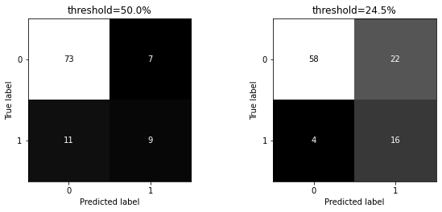

```python
fig, [ax1, ax2] = plt.subplots(ncols=2, figsize=(10, 5))
plot_cmatrix(target.churn, target.stack_prob > .5, ax=ax1, title='threshold=50.0%')
plot_cmatrix(target.churn, target.stack_prob > .245, ax=ax2, title='threshold=24.5%')
pass
```

1. Матрица ошибок (confusion matrix) наглядно демонстрирует баланс между ошибками первого и второго рода:
   1. Ошибки первого рода в верхнем правом углу.
   2. Ошибки второго рода в нижнем левом.
2. При пороге 50%, 11 из 20 уходящих пользователей будут пропущены, а 7 будут неверно классифицированы как уходящие.
3. При пороге 24.5%, всего 4 из 20 уходящих пользователей будут пропущены (лучше), но 22 будут неверно классифицированы как уходящие (хуже).

## 5.3. Демонстрация прогнозирования

```python
def get_conclusion(row):
    if row.churn and not row.stack_pred:
        return 'miss'
    if not row.churn and row.stack_pred:
        return 'false alarm'
    return 'correct'
```

Прогнозирование с выбранным порогом: 24.5%

- Пользователь будет классифицирован как не уходящий (churn=False), если классификатор прогнозирует вероятность `.245` и менее.
- Пользователь будет классифицирован как уходящий (churn=True), если классификатор прогнозирует вероятность более `.245`.

```python
threshold = .245
df_pred = target.churn.to_frame()
df_pred['stack_pred'] = target.stack_prob > threshold
df_pred['conclusion'] = df_pred.apply(get_conclusion, axis='columns')
df_pred.join(X_test).style
```

|  | churn | stack_pred | conclusion | senior_citizen | partner | dependents | phone_service | multiple_lines | online_security | online_backup | device_protection | tech_support | streaming_tv | streaming_movies | paperless_billing | is_male | internet_dsl | internet_fiber | internet_service | contract_one_month | contract_one_year | contract_two_year | pay_auto_transfer | pay_auto_credit | pay_check_email | pay_check_mail | tenure | monthly_charges | total_charges |
| --- | --- | --- | --- | --- | --- | --- | --- | --- | --- | --- | --- | --- | --- | --- | --- | --- | --- | --- | --- | --- | --- | --- | --- | --- | --- | --- | --- | --- | --- |
| 2680 | False | False | correct | False | True | True | True | False | True | True | True | True | True | True | False | True | True | False | True | False | False | True | True | False | False | False | 71 | 85.450000 | 6029.900000 |
| 1764 | False | False | correct | False | True | True | True | True | True | False | True | True | False | True | False | True | True | False | True | False | False | True | False | False | False | True | 63 | 75.700000 | 4676.700000 |
| 2247 | False | False | correct | False | False | False | True | False | False | False | False | False | False | False | False | False | False | False | False | False | False | True | False | True | False | False | 40 | 19.650000 | 830.250000 |
| 3951 | False | False | correct | False | True | False | True | True | True | True | True | True | True | False | False | True | True | False | True | False | False | True | False | False | False | True | 70 | 79.150000 | 5536.500000 |
| 5690 | False | False | correct | False | False | False | False | False | True | False | True | True | True | True | True | True | True | False | True | False | False | True | False | True | False | False | 72 | 61.200000 | 4390.250000 |
| 4996 | False | False | correct | False | False | False | True | True | True | True | False | True | False | True | False | False | True | False | True | False | False | True | False | False | False | True | 47 | 74.050000 | 3496.300000 |
| 4303 | False | False | correct | False | True | False | True | True | False | False | False | False | False | False | False | False | False | False | False | False | False | True | False | False | False | True | 45 | 25.500000 | 1121.050000 |
| 6769 | False | False | correct | False | False | False | True | False | False | False | False | False | False | False | False | True | False | False | False | False | False | True | False | True | False | False | 48 | 19.850000 | 916.000000 |
| 3576 | False | False | correct | False | True | True | True | True | False | False | False | False | False | False | True | False | False | False | False | False | True | False | True | False | False | False | 72 | 23.300000 | 1623.150000 |
| 1610 | False | False | correct | False | True | True | True | False | True | True | False | True | False | False | False | True | True | False | True | False | False | True | False | True | False | False | 51 | 60.500000 | 3121.450000 |
| 268 | True | False | miss | False | False | False | True | False | False | False | False | False | False | False | False | True | False | False | False | False | False | True | False | False | False | True | 59 | 19.350000 | 1099.600000 |
| 5849 | False | False | correct | False | True | False | True | False | False | False | False | False | False | False | True | True | False | False | False | False | False | True | True | False | False | False | 63 | 19.950000 | 1234.800000 |
| 6376 | False | False | correct | False | False | False | True | False | False | False | False | False | False | False | False | True | False | False | False | False | False | True | True | False | False | False | 66 | 19.350000 | 1240.800000 |
| 640 | False | False | correct | False | True | True | True | True | False | False | False | False | False | False | False | True | False | False | False | False | False | True | True | False | False | False | 68 | 25.400000 | 1620.200000 |
| 5487 | False | False | correct | False | False | True | True | False | False | False | False | False | False | False | True | True | False | False | False | False | True | False | False | False | False | True | 33 | 20.150000 | 682.150000 |
| 4108 | False | False | correct | False | True | True | True | False | False | False | False | False | False | False | True | True | False | False | False | False | True | False | True | False | False | False | 33 | 19.450000 | 600.250000 |
| 3234 | False | False | correct | False | True | True | True | False | False | False | False | False | False | False | False | False | False | False | False | False | False | True | False | False | False | True | 24 | 19.700000 | 452.550000 |
| 7012 | False | False | correct | False | True | False | True | True | True | True | False | True | True | True | True | False | True | False | True | False | False | True | False | False | True | False | 62 | 84.950000 | 5150.550000 |
| 1933 | False | False | correct | False | False | False | True | False | False | False | False | False | False | False | True | True | False | False | False | False | True | False | False | False | False | True | 20 | 19.700000 | 415.900000 |
| 1909 | False | False | correct | False | True | True | True | False | False | False | False | False | False | False | False | True | False | False | False | False | True | False | False | False | False | True | 7 | 20.650000 | 150.000000 |
| 4385 | False | False | correct | False | False | False | True | False | False | False | False | False | False | False | True | True | False | False | False | False | True | False | False | False | False | True | 21 | 20.350000 | 422.700000 |
| 6092 | False | False | correct | False | True | False | True | True | True | True | True | True | False | False | True | False | False | True | True | False | False | True | True | False | False | False | 72 | 94.250000 | 6849.750000 |
| 1906 | False | False | correct | False | False | False | False | False | False | True | False | True | False | False | False | True | True | False | True | False | True | False | False | True | False | False | 40 | 36.000000 | 1382.900000 |
| 2982 | False | False | correct | False | True | True | True | False | False | False | False | False | False | False | True | True | False | False | False | False | True | False | False | True | False | False | 52 | 20.850000 | 1071.600000 |
| 1936 | False | False | correct | False | True | False | True | False | True | True | False | True | False | False | True | False | True | False | True | False | True | False | True | False | False | False | 51 | 60.500000 | 3145.150000 |
| 107 | False | False | correct | False | False | False | False | False | True | False | False | False | False | False | False | False | True | False | True | False | True | False | False | False | False | True | 32 | 30.150000 | 927.650000 |
| 4822 | False | False | correct | False | True | True | True | False | True | False | True | True | True | True | True | True | False | True | True | False | False | True | False | True | False | False | 72 | 104.900000 | 7559.550000 |
| 3966 | False | False | correct | False | True | True | True | True | True | True | False | True | True | True | True | True | False | True | True | False | False | True | False | True | False | False | 72 | 107.700000 | 7919.800000 |
| 213 | False | False | correct | False | True | True | True | False | False | False | False | False | False | False | False | False | False | False | False | False | True | False | False | False | True | False | 29 | 20.000000 | 540.050000 |
| 2538 | False | False | correct | False | True | True | False | False | False | False | False | True | True | False | True | True | True | False | True | False | False | True | False | False | True | False | 34 | 40.550000 | 1325.850000 |

[output cut: 70 more lines]

Возможные исходы классификации (колонка *conclusion*):

- `correct` – верный прогноз
- `false alarm` – ложное срабатывание (type I error)
- `miss` – пропуск (type II error)

## 5.4. Предсказание с помощью модели стэкинга

```python
clf = classifiers_fitted['Stacking']
sample = [1, 0, 0, 1, 1, 0, 1, 0, 0, 0, 0, 1, 0, 0, 1, 1, 1, 0, 0, 0, 1, 0,
       0, 66, 80.45, 5224.35]
```

```python
clf.predict([sample])
```

```
array([False])
```

```python
clf.predict_proba([sample])[:, 1]
```

```
array([0.2487913])
```

## 5.5. Возможные ошибки

**Ошибка 1**

```
NotFittedError: This AdaBoostClassifier instance is not fitted yet. Call 'fit' with appropriate arguments before using this estimator.
```

Перед использованием методов `predict()` (или `predict_proba()`) необходимо обучить классификатор с помощью метода `fit()`.

**Ошибка 2**

```
ValueError: Expected 2D array, got 1D array instead:
```

Единственный сэмпл должен быть обернут в массив из 1-го элемента.

Неправильно:

```
clf.predict([1, 0, 0, 1, 1, 0, 1, 0, 0, 0, 0, 1, 0, 0, 1, 1, 1, 0, 0, 0, 1, 0,
       0, 66, 80.45, 5224.35])
```

Правильно:

```
clf.predict([[1, 0, 0, 1, 1, 0, 1, 0, 0, 0, 0, 1, 0, 0, 1, 1, 1, 0, 0, 0, 1, 0,
       0, 66, 80.45, 5224.35]])
```

**Ошибка 3**

```
ValueError: y should be a 1d array, got an array of shape (100, 2) instead.
```

Метод `predict_proba()` в отличии от `predict()` возвращает две колонки. Для бинарной классификации: первая колонка – вероятность class=False, вторая колонка – вероятность class=True.

Неправильно:

```
y_score = clf.predict_proba(X_test)
roc_auc_score(y_test, y_score)
```

Правильно:

```
y_score = clf.predict_proba(X_test)[:, 1]
roc_auc_score(y_test, y_score)
```

**Ошибка 4**

```
ValueError: Classification metrics can't handle a mix of binary and continuous targets
```

Метрика `recall_score` работает с предсказаниями в виде бинарных значений (False/True, 0/1).

Метрика `roc_auc_score` работает с предсказаниями в виде вероятностей ($x \in [0.0, 1.0]$).

Неправильно:

```
y_pred = clf.predict_proba(X_test)[:, 1]
recall_score(y_test, y_pred)
```

Правильно:

```
y_pred = clf.predict(X_test)
recall_score(y_test, y_pred)
```

```python
# Автоматически удалить папку с кэшем (если REMOVE_CACHE=True)

if REMOVE_CACHE:
    shutil.rmtree(CACHE_DIR)
```